# 데이터 과학 – 기초 통계

시계열 데이터 다루기

## 학습 목표

> - 금융공학을 위한 시계열 데이터 기초를 이해한다.
> - 금융데이터를 가져와서 데이터를 정제하는 방식을 살펴본다.

시계열 데이터(time series)는 시간 순서로 배열된 데이터의 한 종류로 시간에 걸쳐 순차적으로 기록된다. 시계열 데이터는 널려있다고 해도 과언은 아니다. 주식수익률 데이터를 포함한 재무데이터, 인플레이션, 소비자 물가를 포함한 각종 경제 관련 데이터 및 시간순으로 정당 지지율도 대표적인 시계열 데이터가 된다.

날짜와 시간을 어떻게 R 자료구조로 표현하는 방법과 실무에서 자주 등장하는 불규칙한 시계열 데이터를 일정 간격을 갖는 시계열 데이터로 변환하는 방법에 대해서는 다음 웹사이트를 참고한다.

- [시간 데이터 기초](http://statkclee.github.io/data-science/ds-date-basics.html)
- [불규칙 시계열 데이터](http://statkclee.github.io/data-science/ds-irregular-time-series.html)

## 1. 시계열 데이터 맛보기

### 1.1. 시계열 데이터 팩키지와 자료구조 [^1]

| 팩키지 | 시계열 객체 | 상세 설명 |
| --- | --- | --- |
| fts | `fts` | C++ 시계열 라이브러리 `tslib`에 대한 R 인터페이스 |
| its | `its` | 불규칙 시계열 데이터를 처리하는 S4 클래스 |
| tseries | `irts` | “POSIXct” 색인을 갖는 불규칙 시계열 객체 |
| timeSeries | `timeSeries` | Rmetrics 팩키지 시계열 유틸리티 |
| tis | `tis` | 시간 색인과 시계열 데이터를 위한 S3 함수와 클래스 |
| stats | `ts`, `mts` | 일정한 시간 간격을 갖는 시계열 객체 |
| zoo | `zoo` | 불규칙 시계열을 포함하고 전체 관측점을 시계열 순으로 색인한 S3 클래스 |
| xts | `xts` | zoo 클래스 확장 |

시계열 데이터를 R에서 담아내는 객체는 다양하다. C++ `tslib`을 R로 가져온 것부터 가장 최근 `xts` 팩키지까지 다양한 방식이 동원된다. 시계열 데이터를 자료구조로 이해할 경우 먼저 등간격을 갖는 일정한 시간 데이터인지, 불규칙한 시간 데이터인지 판단을 해야하고, 그 다음으로 색인여부가 속도와 연관되어 시계열 데이터를 이해하는 중요한 기준이 될 수 있다.

Base 팩키지에 포함된 `ts` 함수를 사용하면 간단한 시계열 데이터를 생성시킬 수 있다. 특히 `window` 함수를 활용하여 특정 기간 데이터도 쉽게 뽑아낼 수 있다.

```r
# 0. 환경설정 --------------------------------------------------------------
library(tidyverse)
library(lubridate)
library(xts)

# 1. 시계열 데이터 --------------------------------------------------------------
## 1.1. 처음부터 생성------------------------------------------------------------
dat <- c(7,5,3,1,3,5,7)
dat_ts <- as.ts(dat)
dat_ts
```

```
Time Series:
Start = 1
End = 7
Frequency = 1
[1] 7 5 3 1 3 5 7
```

```r
dat_1987_ts <- ts(dat, start=1987)
dat_1987_ts
```

```
Time Series:
Start = 1987
End = 1993
Frequency = 1
[1] 7 5 3 1 3 5 7
```

```r
dat_quarter_ts <- ts(dat, start=c(1987,3), frequency=4)
dat_quarter_ts
```

```
     Qtr1 Qtr2 Qtr3 Qtr4
1987              7    5
1988    3    1    3    5
1989    7
```

```r
# 특정기간 뽑아내기
window(dat_quarter_ts, start=c(1987,3), end=c(1988,4))
```

```
     Qtr1 Qtr2 Qtr3 Qtr4
1987              7    5
1988    3    1    3    5
```

> **시계열 자료구조를 활용하는 이유**

> 시계열 자료구조를 활용하는 이유는 다음 맥주생산량 데이터를 통해 이해하면 쉽다. 시계열 자료구조가 아닌 경우 `plot` 함수에 던지게 되면 산점도를 찍게 되지만, 시계열 자료구조를 갖는 경우 각 관측점을 연결한 시각화 산출물을 생성시킨다.

> `xts` 팩키지를 활용하면 불규칙, 규칙 시계열 데이터를 자체 색인을 통해 빠르게 접근하고 다양한 시계열 데이터를 자유로이 다룰 수 있는 도구상자를 지원한다.

```r
## 1.2. 데이터셋에서 불러오기----------------------------------------------------
# 맥주생산량 데이터
beer_df <- read_csv("https://raw.githubusercontent.com/jamesrobertlloyd/gp-structure-search/master/data/raw/TSDL/monthly-beer-production-in-austr.csv")
names(beer_df) <- c("dtime", "beer")

beer_df <- beer_df %>% dplyr::filter(!is.na(beer)) %>% mutate(dtime=ymd(paste0(dtime,"-01")))

# ts 변환
head(beer_df)
```

```
# A tibble: 6 × 2
       dtime  beer
      <date> <dbl>
1 1956-01-01  93.2
2 1956-02-01  96.0
3 1956-03-01  95.2
4 1956-04-01  77.1
5 1956-05-01  70.9
6 1956-06-01  64.8
```

```r
tail(beer_df)
```

```
# A tibble: 6 × 2
       dtime  beer
      <date> <dbl>
1 1995-03-01   152
2 1995-04-01   127
3 1995-05-01   151
4 1995-06-01   130
5 1995-07-01   119
6 1995-08-01   153
```

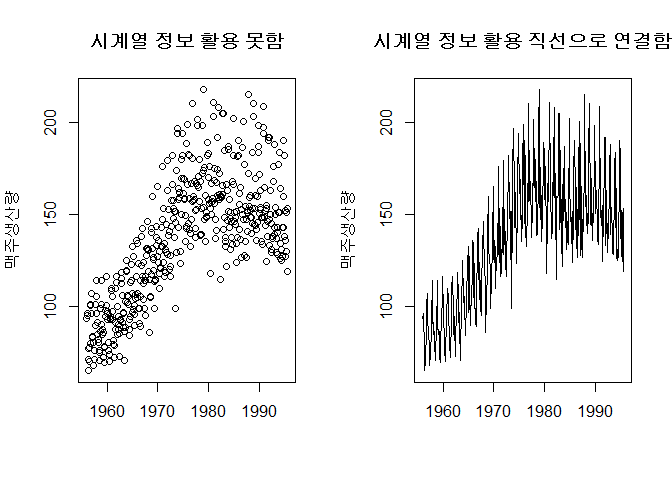

```r
beer_ts <- ts(beer_df[,-1], start=c(1956,01), frequency=12)

par(mfrow=c(1,2))
plot(beer_df, main="시계열 정보 활용 못함", xlab="", ylab="맥주생산량")
plot(beer_ts, main="시계열 정보 활용 직선으로 연결함", xlab="", ylab="맥주생산량")
```

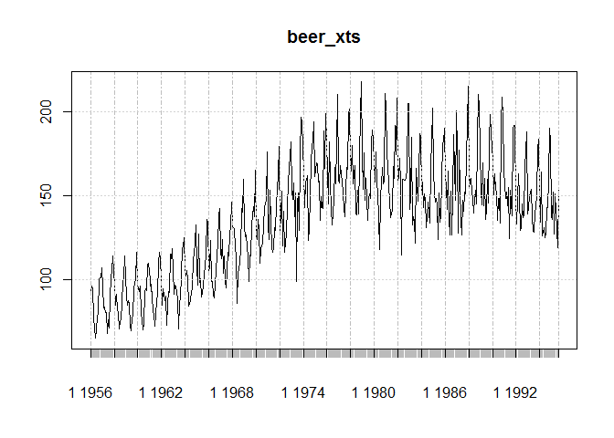

```r
# xts 변환
beer_xts <- as.xts(beer_df[,-1], order.by=beer_df$dtime)

par(mfrow=c(1,1))
plot(beer_xts)
```

### 1.2. 시계열 데이터 시각화 [^2]

시계열 데이터를 시각화할 경우 시계열 시간이 항상 시계열 관측값보다 긴 것이 좋다. 태양의 흑점수(sunspot)를 관측한 데이터의 특징은 흑점개수가 빠르게 증가하고 느리게 감소하는 경향이 있는데 상단 그래프(시간축이 관측축보다 긴 경우)는 이런 경향이 잘 관찰되지만, 하단 그래프(시간축과 관측축이 동일한 경우)는 이런 경향을 확인하기 상대적으로 쉽지 않다.

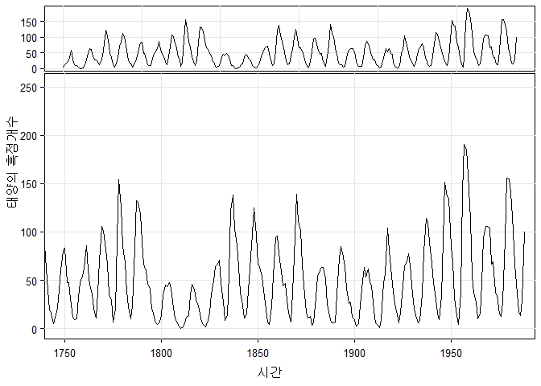

```r
# 2. 시각화----------------------------------------------------
require(graphics)
data(sunspot.year)
layout(matrix(c(1:2, 1:2), ncol=2), height=c(.2,.8))

par(mar=c(.2,3.5,0,.5), oma=c(3.5,0,.5,0), mgp=c(2,.6,0), tcl=-.3, las=1)

plot(sunspot.year, type='n', xaxt='no', ylab='')
  grid(lty=1, col=gray(.9))
  lines(sunspot.year)

plot(sunspots, type='n', ylab='')
  grid(lty=1, col=gray(.9))
  lines(sunspot.year)

title(xlab="시간", outer=TRUE, cex.lab=1.2)
mtext(side=2, "태양의 흑점개수", line=2, las=0, adj=.75)
```

# 2. 시계열 데이터 다루기

## 2.1. 주식 데이터 1종

시계열 데이터의 대표적인 데이터가 주식 데이터로 [특정 기업(웹젠)](http://www.webzen.co.kr/)을 살펴보자.

### 오류

> Error in download.file(paste(yahoo.URL, “s=”, Symbols.name, “&a=”, from.m, : cannot open URL ‘https://ichart.finance.yahoo.com/table.csv?s=069080.KQ&a=0&b=01&c=2017&d=4&e=18&f=2017&g=d&q=q&y=0&z=069080.KQ&x=.csv’ In addition: Warning message: In download.file(paste(yahoo.URL, “s=”, Symbols.name, “&a=”, from.m, : cannot open URL ‘https://ichart.finance.yahoo.com/table.csv?s=069080.KQ&a=0&b=01&c=2017&d=4&e=18&f=2017&g=d&q=q&y=0&z=069080.KQ&x=.csv’: HTTP status was ‘502 Connection refused’

따라서, 아마존을 대상으로 살펴보자. `getSymbols` 함수로 야후나 구글에서 주식데이터를 긁어오면 시가, 종가 등 다양한 정보를 아래 함수를 혹은 조합해서 활용이 가능하다.

- Op() : 개장가격(opening price)
- Hi() : 최고가(high price)
- Lo() : 최저가(low price)
- Cl() : 마감 종가(close price)
- Vo() : 거래량(traded volume)
- Ad() : 조정된 마감 종가(adjusted close price)

```r
# 1. 데이터 긁어오기 ----------------------------------
# webzen_env <- new.env()
# webzen_xts <- getSymbols('069080.KQ', src='yahoo', env=webzen_env, from = "2017-01-01", auto.assign = F)

getSymbols("AMZN", src="google", auto.assign = TRUE, from = "2017-05-01")
```

```
[1] "AMZN"
```

```r
# 2. 특정 칼럼 뽑아내기 ----------------------------------
## 2.1. 한 칼럼만 뽑아내기
head(Op(AMZN), 3)
```

```
           AMZN.Open
2017-05-01    927.80
2017-05-02    946.64
2017-05-03    946.00
```

```r
head(Hi(AMZN), 3)
```

```
           AMZN.High
2017-05-01     954.4
2017-05-02     950.1
2017-05-03     946.0
```

```r
head(Lo(AMZN), 3)
```

```
           AMZN.Low
2017-05-01   927.80
2017-05-02   941.41
2017-05-03   935.90
```

```r
head(Cl(AMZN), 3)
```

```
           AMZN.Close
2017-05-01     948.23
2017-05-02     946.94
2017-05-03     941.03
```

```r
head(Vo(AMZN), 3)
```

```
           AMZN.Volume
2017-05-01     5466544
2017-05-02     3848835
2017-05-03     3582686
```

```r
# head(Ad(AMZN), 3)

## 2.2. 칼럼 다수 뽑아내기

head(OHLC(AMZN), 3)
```

```
           AMZN.Open AMZN.High AMZN.Low AMZN.Close
2017-05-01    927.80     954.4   927.80     948.23
2017-05-02    946.64     950.1   941.41     946.94
2017-05-03    946.00     946.0   935.90     941.03
```

## 2.2. 주식 데이터 다수

주식 데이터 다수를 가져열 경우 일단 `new.env()` 함수로 다수 주식데이터를 담아놓는 공간을 마련한다. 그후 split-apply-combine 전략을 적용한다.

```r
# 3. 다수 데이터 긁어오기 ----------------------------------

data_env <- new.env()
getSymbols(c("AMZN", "AAPL"), env = data_env, src="google", auto.assign = TRUE, from = "2017-05-01")
```

```
[1] "AMZN" "AAPL"
```

```r
## 3.1. 다수 데이터 종가 가져오기

data_lst <- lapply(data_env, Cl)
(closed <- do.call(merge, data_lst))
```

```
           AAPL.Close AMZN.Close
2017-05-01     146.58     948.23
2017-05-02     147.51     946.94
2017-05-03     147.06     941.03
2017-05-04     146.53     937.53
2017-05-05     148.96     934.15
2017-05-08     153.01     949.04
2017-05-09     153.99     952.82
2017-05-10     153.26     948.95
2017-05-11     153.95     947.62
2017-05-12     156.10     961.35
2017-05-15     155.70     957.97
2017-05-16     155.47     966.07
2017-05-17     150.25     944.76
```

[^1]: [Eric Zivot(2014), “Working with Financial Time Series Data in R”](https://faculty.washington.edu/ezivot/econ424/Working%20with%20Time%20Series%20Data%20in%20R.pdf)
[^2]: [The sunspot numbers plotted in different-sized boxes, demonstrating that the dimensions of the graphic matters when displaying time series data](http://www.stat.pitt.edu/stoffer/tsa4/tsaEZ.pdf)